# MOFA tutorial with BeatAML datasets

Junyan Lu

12/15/2021

# Brief description

This dataset is from the BeatAML study: https://www.cancer.gov/about-nci/organization/ccg/blog/2019/beataml, which is very similar to the study of our CLL cohort. Currently, I am using the drug screen, mRNA expression and mutation data from this study. I am also applying for the access to the proteomic data. If I am granted the access, I can perhaps also add the proteomic view here.

# Load packages

```r
library(MOFA2)
library(DESeq2)
library(tidyverse)
```

# Load and preprocess data

## Gene expression matrix

Load expression matrix

```r
exprMat <- read_tsv("processed/rna_count_matrix.tsv") %>%
  data.frame() %>% column_to_rownames("Gene_symbol") %>%
  as.matrix()
```

```r
keepGene <- rowMeans(exprMat) > 10
exprMat <- exprMat[keepGene,]
```

Variance stabilizing transformation

```r
exprMat.vst <- varianceStabilizingTransformation(exprMat, blind=TRUE)
```

Current dimensions

```r
dim(exprMat.vst)
```

```
## [1] 19984   494
```

Only keep top 5000 most variable genes (optional)

```r
sds <- apply(exprMat.vst, 1, sd)
exprMat.filt <- exprMat.vst[order(sds, decreasing = TRUE)[1:5000],]
```

## Drug response

Load drug response as a table

```r
drugTab <- read_tsv("processed/drug_response_table.tsv")
```

Data structure

```r
head(drugTab)
```

```
## # A tibble: 6 × 3
##   inhibitor             lab_id         auc
##   <chr>                 <chr>        <dbl>
## 1 17-AAG (Tanespimycin) AML_12_00211  226.
## 2 17-AAG (Tanespimycin) AML_12_00219  135.
## 3 17-AAG (Tanespimycin) AML_12_00258  165.
## 4 17-AAG (Tanespimycin) AML_12_00262  112.
## 5 17-AAG (Tanespimycin) AML_12_00268  227.
## 6 17-AAG (Tanespimycin) AML_12_00288  113.
```

Change to matrix

```r
drugMat <- drugTab %>%
  pivot_wider(names_from = "lab_id", values_from = "auc") %>%
  data.frame() %>% column_to_rownames("inhibitor") %>%
  as.matrix()
```

Current dimension of the matrix

```r
dim(drugMat)
```

```
## [1] 122 528
```

Remove drugs that have too many NA values (optional). Removed drugs that have been tested in less than 50% of the samples

```r
keepDrug <- rowSums(is.na(drugMat))/ncol(drugMat) < 0.5
drugMat.filt <- drugMat[keepDrug,]
```

Current dimension

```r
dim(drugMat.filt)
```

```
## [1] 105 528
```

## Load gene mutation table

```r
geneTab <- read_tsv("processed/gene_mutation_table.tsv")
geneTab
```

```
## # A tibble: 4,138 × 3
##    lab_id       gene     value
##    <chr>        <chr>    <dbl>
##  1 AML_09_00705 FLT3.ITD     1
##  2 AML_09_00705 NPM1         1
##  3 AML_09_00705 FLT3         0
##  4 AML_09_00705 JAK2         0
##  5 AML_09_00705 KIT          0
##  6 AML_10_00136 FLT3.ITD     1
##  7 AML_10_00136 NPM1         0
##  8 AML_10_00136 CEBPA        0
##  9 AML_10_00172 FLT3.ITD     1
## 10 AML_10_00172 NPM1         0
## # … with 4,128 more rows
```

Change to matrix

```r
geneMat <- geneTab %>%
  pivot_wider(names_from = "lab_id", values_from = "value") %>%
  data.frame() %>% column_to_rownames("gene") %>%
  as.matrix()
```

Current dimensions

```r
dim(geneMat)
```

```
## [1]  15 671
```

There are quite some missing values (NA) in the data matrix. We will keep them, as MOFA should be able to deal with them.

```r
str(geneMat)
```

```
##  num [1:15, 1:671] 1 1 0 0 0 NA NA NA NA NA ...
##  - attr(*, "dimnames")=List of 2
##   ..$ : chr [1:15] "FLT3.ITD" "NPM1" "FLT3" "JAK2" ...
##   ..$ : chr [1:671] "AML_09_00705" "AML_10_00136" "AML_10_00172" "AML_10_00507" ...
```

# Prepare MOFA model

## Create MOFA object

Generate a long data frame

```r
AML_df <- bind_rows(
  drugMat.filt %>% as_tibble(rownames = "feature") %>%
    pivot_longer(-feature, names_to = "sample", values_to = "value") %>%
    mutate(view = "Drugs"),
  exprMat.filt %>% as_tibble(rownames = "feature") %>%
    pivot_longer(-feature, names_to = "sample", values_to = "value") %>%
    mutate(view = "mRNA"),
  geneMat %>% as_tibble(rownames = "feature") %>%
    pivot_longer(-feature, names_to = "sample", values_to = "value") %>%
    mutate(view = "Mutations"),
)
```

We would like to keep the samples that have at least two view (optional)

```r
viewSum <- AML_df %>%
  distinct(sample, view) %>%
  group_by(sample) %>%
  summarise(nView = length(view)) %>%
  filter(nView >=2)

AML_df.filt <- AML_df %>% filter(sample %in% viewSum$sample)
```

Create MOFA object

```r
MOFAobject <- create_mofa(AML_df.filt)
```

```
## Creating MOFA object from a data.frame...
```

Plot data overview

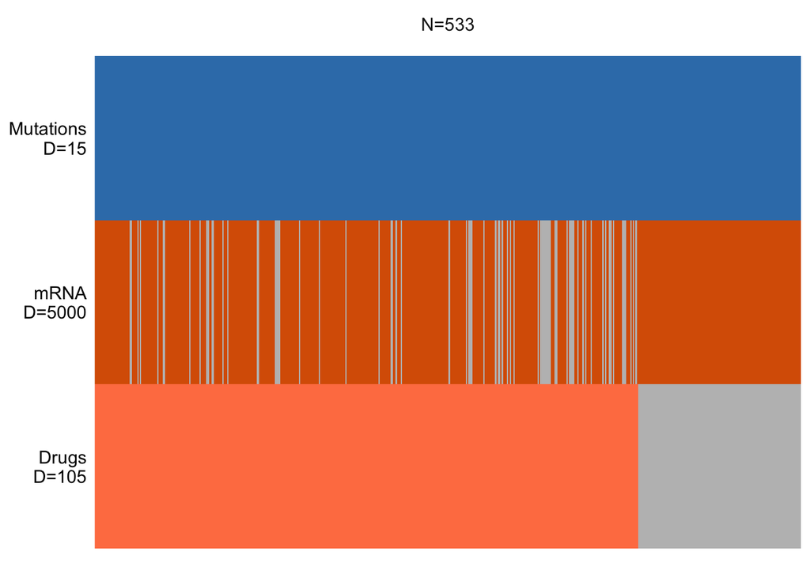

```r
plot_data_overview(MOFAobject)
```

## Define MOFA options

### Data options

```r
data_opts <- get_default_data_options(MOFAobject)
data_opts
```

```
## $scale_views
## [1] FALSE
##
## $scale_groups
## [1] FALSE
##
## $center_groups
## [1] TRUE
##
## $use_float32
## [1] FALSE
##
## $views
## [1] "Drugs"     "mRNA"      "Mutations"
##
## $groups
## [1] "single_group"
```

### Model options

```r
model_opts <- get_default_model_options(MOFAobject)
model_opts$num_factors <- 20

model_opts
```

```
## $likelihoods
##      Drugs       mRNA  Mutations
## "gaussian" "gaussian" "gaussian"
##
## $num_factors
## [1] 20
##
## $spikeslab_factors
## [1] FALSE
##
## $spikeslab_weights
## [1] TRUE
##
## $ard_factors
## [1] FALSE
##
## $ard_weights
## [1] TRUE
```

Change the likely hood of Mutations to "bernoulli

```r
model_opts$likelihoods[["Mutations"]] <- "bernoulli"
model_opts$likelihoods
```

```
##       Drugs        mRNA   Mutations
##  "gaussian"  "gaussian" "bernoulli"
```

### Training options

```r
train_opts <- get_default_training_options(MOFAobject)
train_opts$convergence_mode <- "slow"
train_opts$seed <- 2022

train_opts
```

```
## $maxiter
## [1] 1000
##
## $convergence_mode
## [1] "slow"
##
## $drop_factor_threshold
## [1] -1
##
## $verbose
## [1] FALSE
##
## $startELBO
## [1] 1
##
## $freqELBO
## [1] 5
##
## $stochastic
## [1] FALSE
##
## $gpu_mode
## [1] FALSE
##
## $seed
## [1] 2022
##
## $outfile
## NULL
##
## $weight_views
## [1] FALSE
##
## $save_interrupted
## [1] FALSE
```

# Train the MOFA model

Prepare MOFA object

```r
MOFAobject <- prepare_mofa(MOFAobject,
  data_options = data_opts,
  model_options = model_opts,
  training_options = train_opts
)
```

```
## Checking data options...
```

```
## Checking training options...
```

```
## Checking model options...
```

Training

```r
MOFAobject <- run_mofa(MOFAobject)
saveRDS(MOFAobject,"output/mofaAML.rds")
```

# Preliminary analysis of the results

```r
MOFAobject <- readRDS("output/mofaAML.rds")
```

```r
slotNames(MOFAobject)
```

```
##  [1] "data"               "covariates"         "covariates_warped"
##  [4] "intercepts"         "imputed_data"       "interpolated_Z"
##  [7] "samples_metadata"   "features_metadata"  "expectations"
## [10] "training_stats"     "data_options"       "model_options"
## [13] "training_options"   "stochastic_options" "mefisto_options"
## [16] "dimensions"         "on_disk"            "dim_red"
## [19] "cache"              "status"
```

Factor correlation matrix

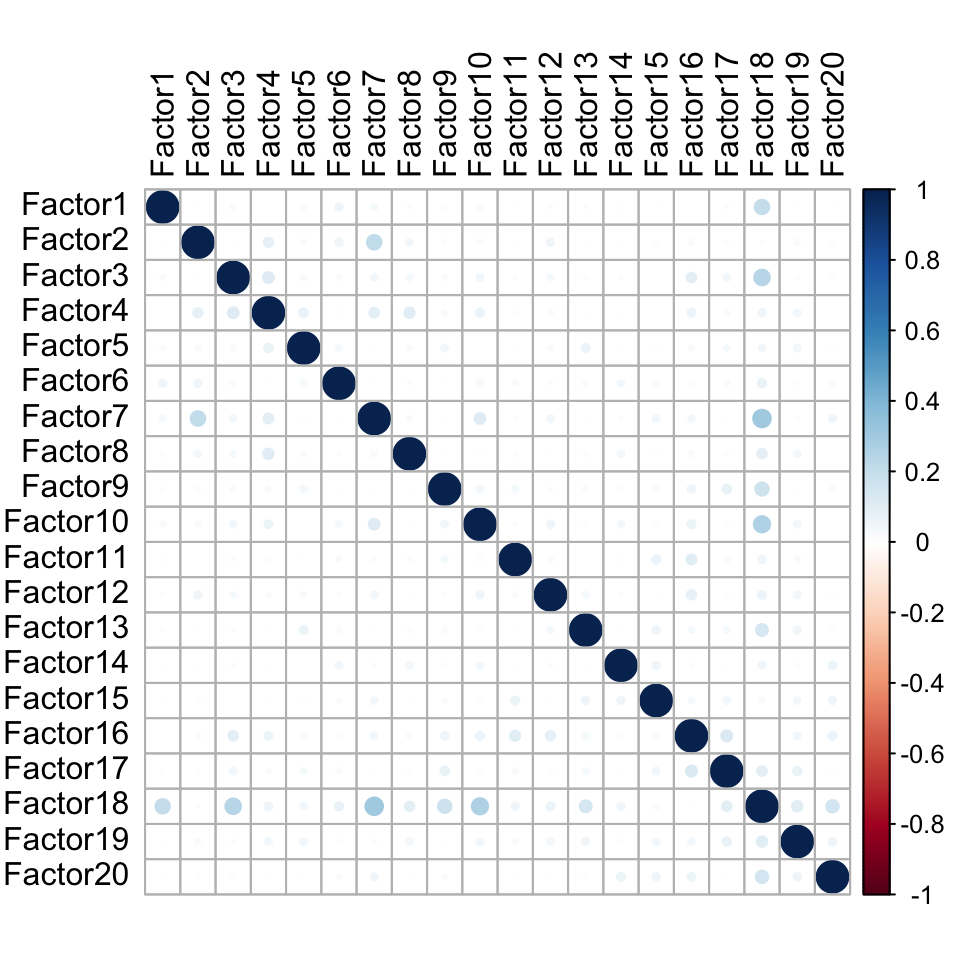

```r
plot_factor_cor(MOFAobject)
```

Variance explained

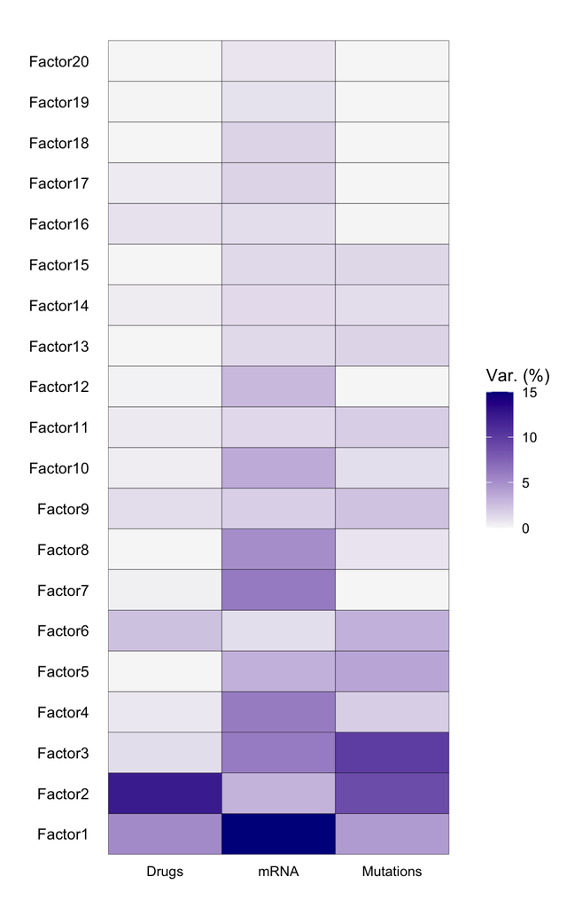

```r
plot_variance_explained(MOFAobject, max_r2=15)
```

Total variance explained

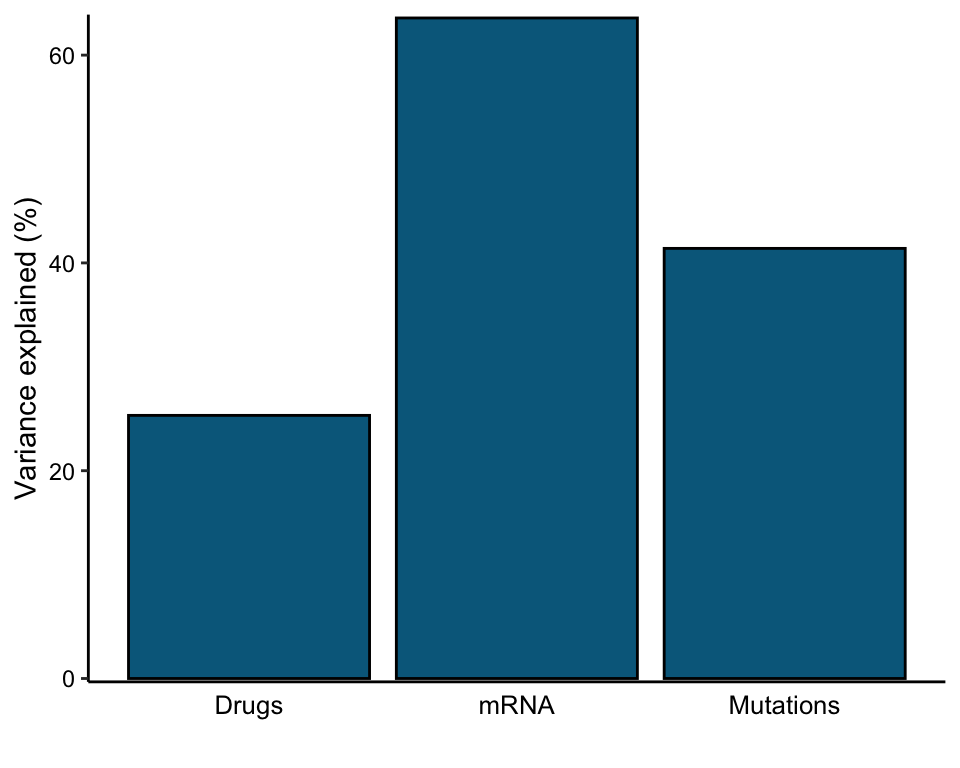

```r
plot_variance_explained(MOFAobject, plot_total = T)[[2]]
```

Factor 1 values

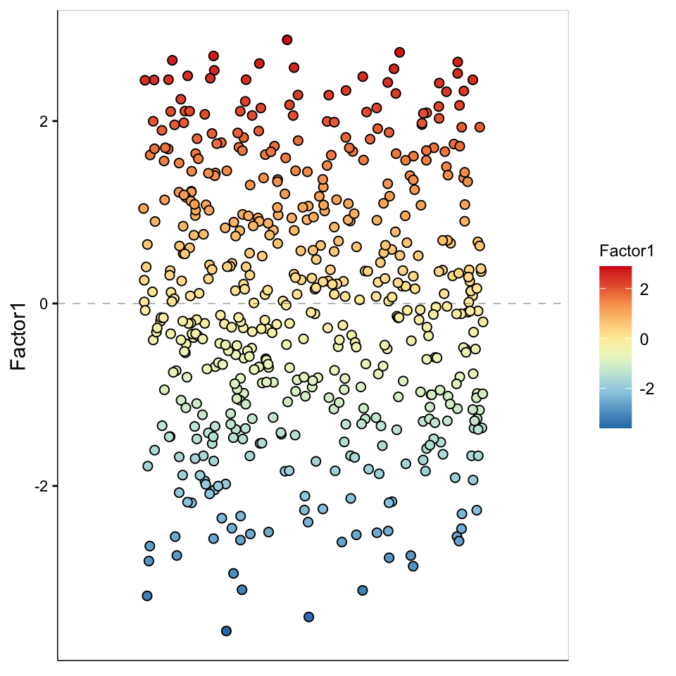

```r
plot_factor(MOFAobject,
  factors = 1,
  color_by = "Factor1"
)
```

Weight of genomic features on LF1

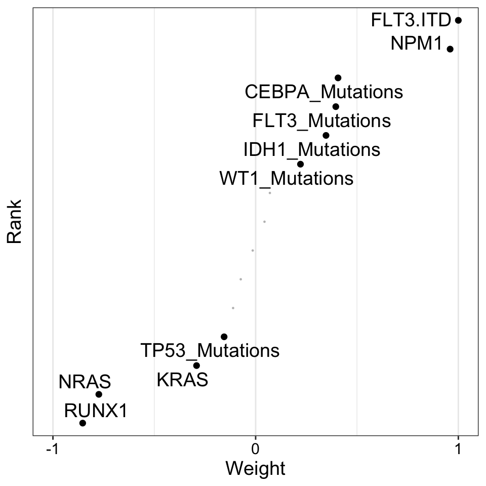

```r
plot_weights(MOFAobject,
 view = "Mutations",
 factor = 1,
 nfeatures = 10,     # Top number of features to highlight
 scale = T           # Scale weights from -1 to 1
)
```

LF1 is associated with one of the most common mutation FLT3.ITD in AML.

Weight of genomic features on LF1

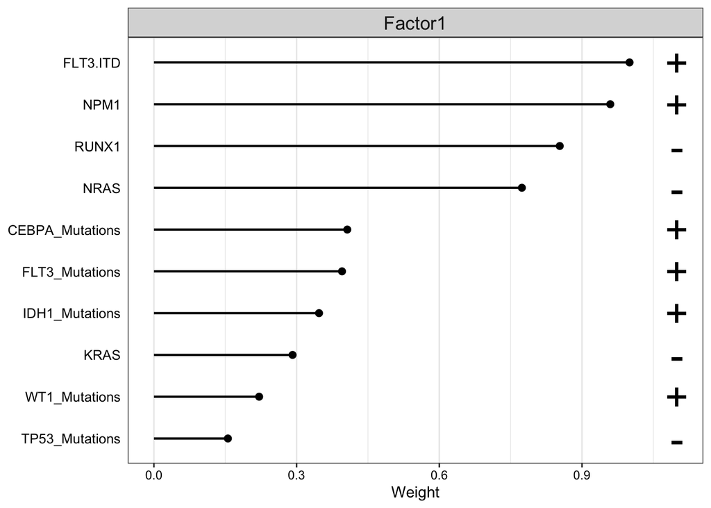

```r
plot_top_weights(MOFAobject,
 view = "Mutations",
 factor = 1,
 nfeatures = 10,     # Top number of features to highlight
 scale = T           # Scale weights from -1 to 1
)
```

LF1 values versus FLT3.ITD mutation

[figure not shown]

```r
plot_factor(MOFAobject,
  factors = 1,
  color_by = "FLT3.ITD",
  add_violin = TRUE,
  dodge = TRUE
)
```

**Students are encouraged to run other down-stream analysis to further explore LF1, e.g. what are the drugs related to LF1 and what’s the pathway changes related to LF1?**

**Also explore other factors**